# Machine learning_coursera_peoject

DLE

24 avril 2018

## Data Analysis

The goal of this analysis is to deepens our understading of activity types and predict the class (types of actvitities) the participants have made

#### Importing the Data

Starting by importing the data and printing a preview of the training data to console We also select only the variable that have less than 30% of missing values in order to lighten the futur PCA, plotting and model

```r
testing_data=read.csv("pml-testing.csv",header=T,sep=",",quote = "")


training_data=read.csv("pml-training.csv",header=T,sep=",",quote = "")

head(training_data[1:5,1:5])
```

```
##   X. X..user_name.. X..raw_timestamp_part_1.. X..raw_timestamp_part_2..
## 1 "1   ""carlitos""                1323084231                    788290
## 2 "2   ""carlitos""                1323084231                    808298
## 3 "3   ""carlitos""                1323084231                    820366
## 4 "4   ""carlitos""                1323084232                    120339
## 5 "5   ""carlitos""                1323084232                    196328
##    X..cvtd_timestamp..
## 1 ""05/12/2011 11:23""
## 2 ""05/12/2011 11:23""
## 3 ""05/12/2011 11:23""
## 4 ""05/12/2011 11:23""
## 5 ""05/12/2011 11:23""
```

```r
training_data <- data.frame(lapply(training_data,FUN=function(x){
                  gsub('""""',NA,x)
                  }))
training_data <- data.frame(lapply(training_data,FUN=function(x){
                  gsub('"',"",x)}))

testing_data <- data.frame(lapply(testing_data,FUN=function(x){
                  gsub('""""',NA,x)
                  }))
testing_data <- data.frame(lapply(testing_data,FUN=function(x){
                  gsub('"',"",x)}))

# remove column that are filed with Nas
to_keep <- colSums(is.na(training_data))/length(training_data$X.) <0.3
to_keep <- names(training_data)[to_keep]


training_cleaned <- training_data %>% select(to_keep)

to_keep_name_testing <- names(testing_data) %in% names(training_data)

training_cleaned <- training_cleaned[,to_keep]


training_cleaned$X..classe... <- as.factor(training_cleaned$X..classe...)


training_cleaned$X..raw_timestamp_part_1.. <- as.numeric(training_cleaned$X..raw_timestamp_part_1.. )
#
training_cleaned$X..raw_timestamp_part_2.. <- as.numeric(training_cleaned$X..raw_timestamp_part_2..)
to_keep <- colSums(is.na(testing_data))/length(testing_data$X.) <0.3
to_keep <- names(testing_data)[to_keep]
for (eachrow in seq(5,59)){
  training_cleaned[,eachrow] <- as.numeric(training_cleaned[,eachrow])

}

training_cleaned_all <- training_cleaned

rm(training_data)




testing_cleaned <- testing_data %>% select(to_keep)


testing_cleaned<- testing_cleaned[,to_keep]
```

#### Data Division

```r
intraining <- createDataPartition(training_cleaned_all$X..user_name..,p=0.7,list=F)
training_cleaned <- training_cleaned_all[intraining,]
training_for_testing <- training_cleaned_all[-intraining,]

dim(training_cleaned)
```

```
## [1] 13738    60
```

```r
dim(training_for_testing)
```

```
## [1] 5884   60
```

## Training Variable plots

In this following graph we can see a plot for multiple variables ( the five first variable in the dataset) while this graph cannot teach us much due to the structure of the data it is still an interesting methodology to present.in order to complete the PCA, we started by converting the numerical variable from the factor variable.

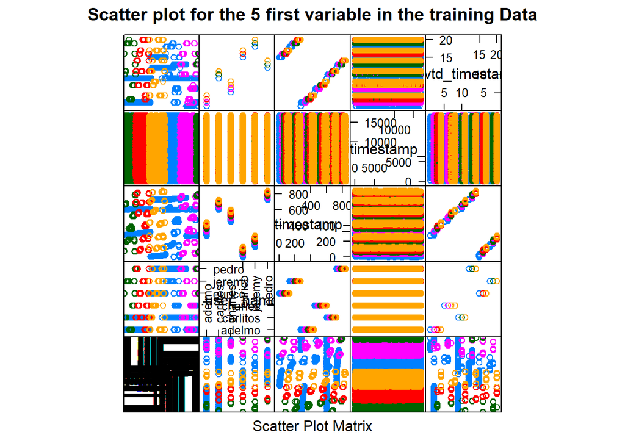

#### Variable Selection

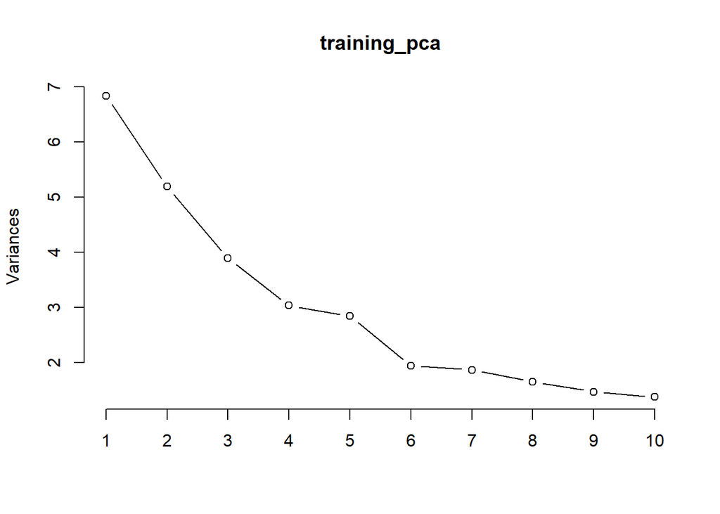

```r
training_pca <- prcomp(training_cleaned[5:59],center=T,scale.=T)

pca_table <- data.frame(training_pca$rotation)
sum_pca <- summary(training_pca)

screeplot(training_pca,type="line")
```

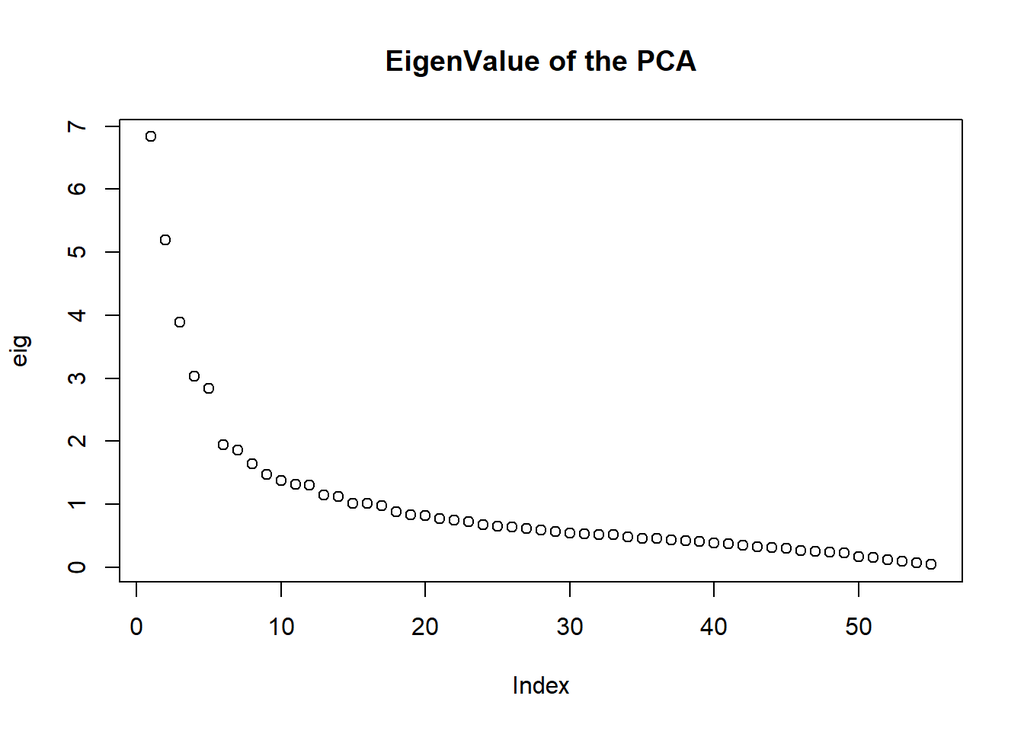

```r
eig <- (training_pca$sdev)^2

plot(eig,main="EigenValue of the PCA")
```

#### Model building

As stated before, we will build a model. the model will be a random forest usng the 18 first quantitatibe variable as well as all the factor variable converted in factor variable. the date were converted to numerical.

My model ran on a Virtual machine and then imported on my local computer. The VM was 32 GRAM and 8 cores.

```r
df_train1 <- training_cleaned[,c(2:24,60)]
#
#
#
#
# cluster <- makeCluster(detectCores(logical=F)-1)
# registerDoParallel(cluster)
#
# control <- trainControl(method="cv", number=4,allowParallel = TRUE)
#
#
# set.seed(123)
#
# train_model_1 <- train(y=as.factor(df_train1$X..classe...),x= df_train1[,2:ncol(df_train1)-1], method="rf",trainControl=control,model = FALSE,verbose=FALSE)
#
# stopCluster(cluster)
#SaveRDS(train_model_1.RDS,"train_model_1.RDS")
```

## Model visualization

The First table is a summary for the confusion matrix. we can see that our model fit the training dataset highly.

```r
train_model_1 <- readRDS("C:/Users/David/OneDrive/Coursera/Machine learning/train_model_1.RDS")


print(train_model_1)
```

```
## Random Forest
##
## 13738 samples
##    23 predictor
##     5 classes: 'A', 'B', 'C', 'D', 'E'
##
## No pre-processing
## Resampling: Bootstrapped (25 reps)
## Summary of sample sizes: 13738, 13738, 13738, 13738, 13738, 13738, ...
## Resampling results across tuning parameters:
##
##   mtry  Accuracy   Kappa
##    2    0.9960887  0.9950548
##   12    0.9985996  0.9982296
##   23    0.9969096  0.9960931
##
## Accuracy was used to select the optimal model using the largest value.
## The final value used for the model was mtry = 12.
```

```r
print(train_model_1$finalModel$confusion)
```

```
##      A    B    C    D    E  class.error
## A 3873    0    0    0    0 0.0000000000
## B    1 2698    1    0    0 0.0007407407
## C    0    1 2389    2    0 0.0012541806
## D    0    0    2 2252    0 0.0008873114
## E    1    0    0    1 2517 0.0007939659
```

The actual fitting on the trainded model for the trained section gives us an accuracy of 0.9985.

## Prediction on the Testing portion of the training Data

We will now predict on the testing dataset

```r
df_check_train <- training_for_testing[,c(2:24,60)]
prediction_confirmation_training <- predict(train_model_1,newdata=df_check_train[,-24])

cmtree_conf <- confusionMatrix(prediction_confirmation_training,df_check_train$X..classe...)


print(cmtree_conf)
```

```
## Confusion Matrix and Statistics
##
##           Reference
## Prediction    A    B    C    D    E
##          A  715  236  237   58    0
##          B    1  180    1    0    0
##          C    0    0   16    0    0
##          D    0   30  148  213    7
##          E  909  687  663  680 1103
##
## Overall Statistics
##
##                Accuracy : 0.3785
##                  95% CI : (0.3661, 0.391)
##     No Information Rate : 0.2762
##     P-Value [Acc > NIR] : < 2.2e-16
##
##                   Kappa : 0.2178
##  Mcnemar's Test P-Value : < 2.2e-16
##
## Statistics by Class:
##
##                      Class: A Class: B Class: C Class: D Class: E
## Sensitivity            0.4400  0.15887 0.015023  0.22397   0.9937
## Specificity            0.8753  0.99958 1.000000  0.96250   0.3844
## Pos Pred Value         0.5738  0.98901 1.000000  0.53518   0.2729
## Neg Pred Value         0.8038  0.83287 0.821234  0.86548   0.9962
## Prevalence             0.2762  0.19256 0.180999  0.16162   0.1886
## Detection Rate         0.1215  0.03059 0.002719  0.03620   0.1875
## Detection Prevalence   0.2118  0.03093 0.002719  0.06764   0.6869
## Balanced Accuracy      0.6577  0.57922 0.507512  0.59324   0.6890
```

In order to Cross Validate i would run a model rpart with the same specification.

In real life here is the next step i would do to improve my model: - i would run the RF on the full spectrum of available variable - i would preprocess the quantitative variables where i would center and scale the variables. - i would tune the parameters

because i had to borrow a virtual machine to run the test it is difficult to make adjustment to the current model and it is clear that the goal is not to have the best model but tu understant the underlying mechanism.

#### Prediction of OOS on the test set

```r
# we first need to configurate the testing dataset as the training dataset
same_name <- names(testing_cleaned) %in% names(df_train1)
to_keep <- names(testing_cleaned)[same_name]


testing_cleaned <- testing_cleaned[,to_keep]
testing_cleaned$X..raw_timestamp_part_1.. <- as.numeric(testing_cleaned$X..raw_timestamp_part_1..)
testing_cleaned$X..raw_timestamp_part_2.. <- as.numeric(testing_cleaned$X..raw_timestamp_part_2..)

for (eachrow in seq(4,23)){
  testing_cleaned[,eachrow] <- as.numeric(testing_cleaned[,eachrow])

}



prediction_model_1 <- predict(train_model_1$finalModel,newdata=testing_cleaned)

cmtree <- confusionMatrix(prediction_model_1,prediction_model_1)
```